# R Notebook

## Job Title

This is so confusing. The term “Data Science” and “DataScientist”. The wide areas of fields datascientists works are in exponential.This makes it difficult to give a stable definition to the same. Its the same as that of over-hyped use of AI,it seems.For every other products, it is backed by AI !!! So, its not surprising if i say that there are datascientists with 1 year of work experience in the industry. Iam really excited to see what the world thinks.

```r
multiple%>%
  count(`Select the title most similar to your current role (or most recent title if retired): - Selected Choice`) %>%
  arrange(n)%>%
  hchart(type = "column", hcaes(x = `Select the title most similar to your current role (or most recent title if retired): - Selected Choice`, y = n))
```

```r
multiple%>%
  count(`Do you consider yourself to be a data scientist?`) %>%
  arrange(n)%>%
  hchart(type = "column", hcaes(x = `Do you consider yourself to be a data scientist?`, y = n))
```

```r
library(treemap)

library(viridisLite)

data(GNI2014)

tm <- treemap(multiple, index = c("continent", "iso3"),
              vSize = "population", vColor = "GNI",
              type = "value", palette = viridis(6))
```

```r
leaflet(loan_themes_region) %>% addProviderTiles("Esri.NatGeoWorldMap") %>%
  addCircles(lng = ~lon, lat = ~lat,radius = ~(amount/10) ,
             color = ~c("red"))  %>%
  # controls
  setView(lng=0, lat=0,zoom = 2)
```

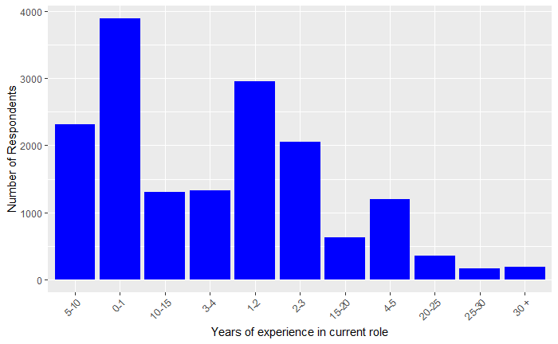

```r
experience_levels <- c("0-1", "1-2", "2-3", "3-4", "4-5", "5-10", "10-15", "15-20", "20-25", "25-30", "30 +", "")
multiple <- multiple %>% mutate(experience = fct_relevel(`How many years of experience do you have in your current role?`, experience_levels))
multiple %>% filter(`Select the title most similar to your current role (or most recent title if retired): - Selected Choice`!="Student" & `How many years of experience do you have in your current role?`!="") %>% count(`How many years of experience do you have in your current role?`) %>%
        ggplot(aes(x=`How many years of experience do you have in your current role?`, y=n)) +
        geom_col(fill="blue") +
        theme(axis.text.x = element_text(angle = 45, hjust = 1)) +
        labs(x="Years of experience in current role", y="Number of Respondents")
```

```r
multiple <- multiple %>%
        rename(Python_user = "What programming languages do you use on a regular basis? (Select all that apply) - Selected Choice - Python",
               R_user = "What programming languages do you use on a regular basis? (Select all that apply) - Selected Choice - R",

               industry = "In what industry is your current employer/contract (or your most recent employer if retired)? - Selected Choice",

               analyze_business = "Select any activities that make up an important part of your role at work: (Select all that apply) - Selected Choice - Analyze and understand data to influence product or business decisions",
               machine_learning = "Select any activities that make up an important part of your role at work: (Select all that apply) - Selected Choice - Build and/or run a machine learning service that operationally improves my product or workflows",
               prototype = "Select any activities that make up an important part of your role at work: (Select all that apply) - Selected Choice - Build prototypes to explore applying machine learning to new areas",
               build_infrastructure = "Select any activities that make up an important part of your role at work: (Select all that apply) - Selected Choice - Build and/or run the data infrastructure that my business uses for storing, analyzing, and operationalizing data",
               research_ml = "Select any activities that make up an important part of your role at work: (Select all that apply) - Selected Choice - Do research that advances the state of the art of machine learning",
               years_code = "How long have you been writing code to analyze data?",
               years_ML = "For how many years have you used machine learning methods (at work or in school)?",
               Jupyter_iPython = "Which of the following integrated development environments (IDE's) have you used at work or school in the last 5 years? (Select all that apply) - Selected Choice - Jupyter/IPython",
               RStudio = "Which of the following integrated development environments (IDE's) have you used at work or school in the last 5 years? (Select all that apply) - Selected Choice - RStudio",
               most_often = "What specific programming language do you use most often? - Selected Choice",
               tensorflow = "What machine learning frameworks have you used in the past 5 years? (Select all that apply) - Selected Choice - TensorFlow",
               keras = "What machine learning frameworks have you used in the past 5 years? (Select all that apply) - Selected Choice - Keras",
               pytorch = "What machine learning frameworks have you used in the past 5 years? (Select all that apply) - Selected Choice - PyTorch",
               caret = "What machine learning frameworks have you used in the past 5 years? (Select all that apply) - Selected Choice - Caret",
               scikit = "What machine learning frameworks have you used in the past 5 years? (Select all that apply) - Selected Choice - Scikit-Learn",
              spark = "What machine learning frameworks have you used in the past 5 years? (Select all that apply) - Selected Choice - Spark MLlib",
              h2o = "What machine learning frameworks have you used in the past 5 years? (Select all that apply) - Selected Choice - H20",
              fast_ai = "What machine learning frameworks have you used in the past 5 years? (Select all that apply) - Selected Choice - Fastai",
              mxnet = "What machine learning frameworks have you used in the past 5 years? (Select all that apply) - Selected Choice - Mxnet",
              xgboost = "What machine learning frameworks have you used in the past 5 years? (Select all that apply) - Selected Choice - Xgboost",
              mlr = "What machine learning frameworks have you used in the past 5 years? (Select all that apply) - Selected Choice - mlr",
              prophet = "What machine learning frameworks have you used in the past 5 years? (Select all that apply) - Selected Choice - Prophet",
              random_forest = "What machine learning frameworks have you used in the past 5 years? (Select all that apply) - Selected Choice - randomForest",
              lightgbm = "What machine learning frameworks have you used in the past 5 years? (Select all that apply) - Selected Choice - lightgbm",
              catboost = "What machine learning frameworks have you used in the past 5 years? (Select all that apply) - Selected Choice - catboost",
              cntk = "What machine learning frameworks have you used in the past 5 years? (Select all that apply) - Selected Choice - CNTK",
              caffe = "What machine learning frameworks have you used in the past 5 years? (Select all that apply) - Selected Choice - Caffe",
              no_ml_packages = "What machine learning frameworks have you used in the past 5 years? (Select all that apply) - Selected Choice - None",
              ml_most_used = "Of the choices that you selected in the previous question, which ML library have you used the most? - Selected Choice",
              degree = "What is the highest level of formal education that you have attained or plan to attain within the next 2 years?",
              ggplot = "What data visualization libraries or tools have you used in the past 5 years? (Select all that apply) - Selected Choice - ggplot2",
              matplotlib = "What data visualization libraries or tools have you used in the past 5 years? (Select all that apply) - Selected Choice - Matplotlib",
              altair = "What data visualization libraries or tools have you used in the past 5 years? (Select all that apply) - Selected Choice - Altair",
              shiny = "What data visualization libraries or tools have you used in the past 5 years? (Select all that apply) - Selected Choice - Shiny",
              d3 = "What data visualization libraries or tools have you used in the past 5 years? (Select all that apply) - Selected Choice - D3",
              plotly = "What data visualization libraries or tools have you used in the past 5 years? (Select all that apply) - Selected Choice - Plotly",
              bokeh = "What data visualization libraries or tools have you used in the past 5 years? (Select all that apply) - Selected Choice - Bokeh",
              seaborn = "What data visualization libraries or tools have you used in the past 5 years? (Select all that apply) - Selected Choice - Seaborn",
              geoplotlib = "What data visualization libraries or tools have you used in the past 5 years? (Select all that apply) - Selected Choice - Geoplotlib",
              leaflet = "What data visualization libraries or tools have you used in the past 5 years? (Select all that apply) - Selected Choice - Leaflet",
              lattice = "What data visualization libraries or tools have you used in the past 5 years? (Select all that apply) - Selected Choice - Lattice",
              no_viz_libraries = "What data visualization libraries or tools have you used in the past 5 years? (Select all that apply) - Selected Choice - None",
              viz_lib_used_most = "Of the choices that you selected in the previous question, which specific data visualization library or tool have you used the most? - Selected Choice",
              salary = "What is your current yearly compensation (approximate $USD)?",
              current_role = "Select the title most similar to your current role (or most recent title if retired): - Selected Choice",
              experience = "How many years of experience do you have in your current role?",
              Q48 = "Do you consider ML models to be \"\"black boxes\"\" with outputs that are difficult or impossible to explain?")
```